# BlandAltmanLeh Intro

Bernhard Lehnert

Dec, 15 2015

# Bland-Altman-Plots

Bland-Altman plots are a well established method to check the agreement of different measurement methods or the retest-reliability of a single measurement method. (Apparently, Bland-Altman plots are otherwise known as Tukey’s Mean Difference Plot.) They do not come included in R but can easily be produced using R (find different packages at the end of this document). The BlandAltmanLeh package tries to make Bland-Altman plots even more accessible. It also features confidence intervals and the combination of Bland-Altman-/Tukey Mean Difference Plot and sunflower plot.

This package is based on the 1986 publication of JM Bland and DG Altman. It is available for free download on http://www-users.york.ac.uk/~mb55/meas/ba.htm Written for medical doctors, this article is very well readable for the non-statistician and thus highly recommended.

## What’s the main idea behind Bland-Altman plots?

Imagine, you’ve measured some parameter with two different measurements at different times or under differing conditions. Let’s say you have measured the following dependend measurements.

```r
A <- c(-0.358, 0.788, 1.23, -0.338, -0.789, -0.255, 0.645, 0.506,
0.774, -0.511, -0.517, -0.391, 0.681, -2.037, 2.019, -0.447,
0.122, -0.412, 1.273, -2.165)
B <- c(0.121, 1.322, 1.929, -0.339, -0.515, -0.029, 1.322, 0.951,
0.799, -0.306, -0.158, 0.144, 1.132, -0.675, 2.534, -0.398, 0.537,
0.173, 1.508, -1.955)
```

Your first attempt to inspect these data may be a scatter plot like

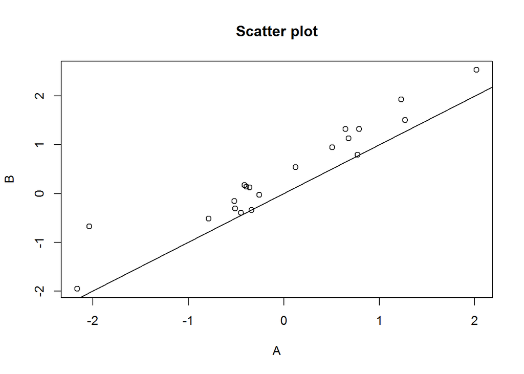

```r
plot(A, B, main="Scatter plot")
abline(0,1)
```

Bland and Altman propose a different approach, where the x axis is the mean of two measurements each and the y axis is the difference between them.

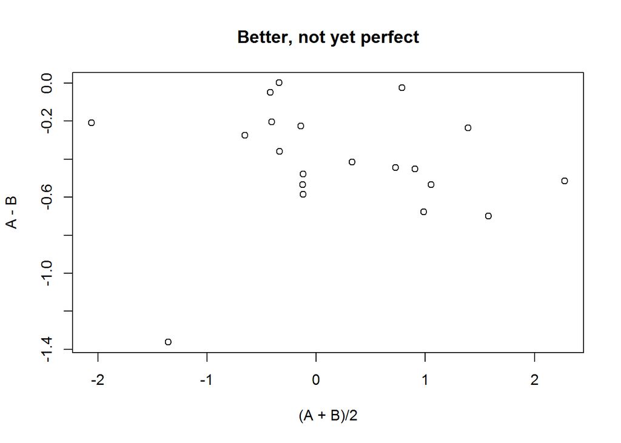

```r
plot((A+B)/2, A-B, main="Better, not yet perfect")
```

Now three additional lines are added for the mean of the differences and 2 (1,96 resp.) standard deviations above and below that.

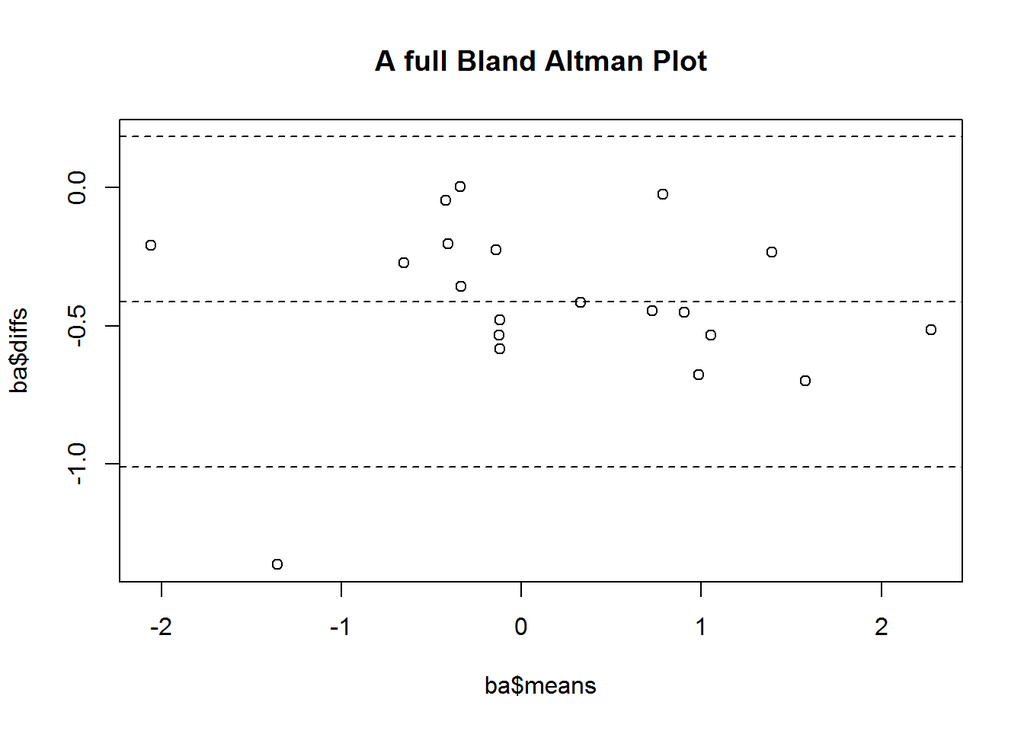

```r
library(BlandAltmanLeh)
bland.altman.plot(A, B, main="A full Bland Altman Plot")
```

## ggplot2

Of course you might be inclined to draw that using ggplot2:

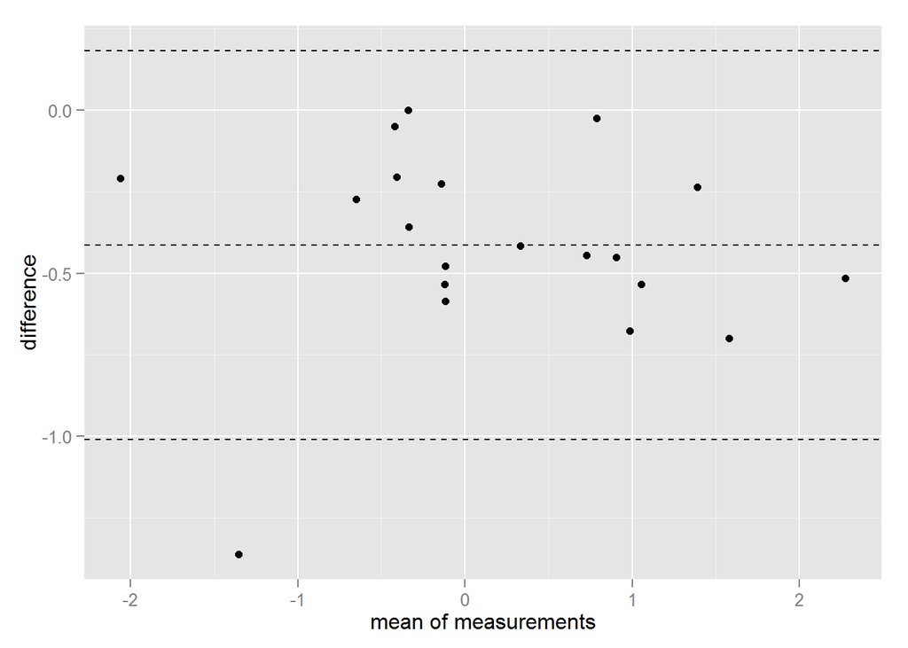

```r
library(ggplot2)
pl <- bland.altman.plot(A, B, graph.sys = "ggplot2")
```

Which is mainly a matter of taste. (like in this poster where we wanted the ggplot2-look for the histogram and thus opted for the ggplot2 Bland Altman plot for consistency: http://www.egms.de/static/pdf/journals/cpo/2015-11/cpo001163.pdf Lehnert B, Vogel S, Hosemann W, GMS Curr Posters Otorhinolaryngol Head Neck Surg 2015; 11:Doc198 (20150416) )

As you can see, 1 out of 20 data points in the figure above falls out of the 95% confidence interval depicted by the upper and lower line. That’s just what one would expect.

Of course, these lines have an error margin and Bland and Altman 1986 describe how to compute confidence intervals for the lines. These can also be calculated and printed with the BlandAltmanLeh package as in:

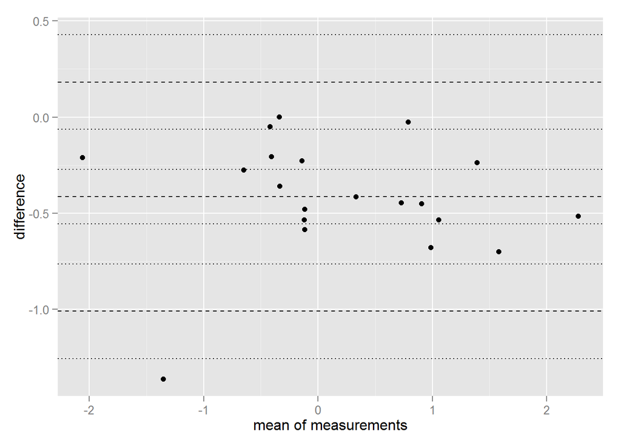

```r
pl <- bland.altman.plot(A, B, graph.sys="ggplot2", conf.int=.95)
```

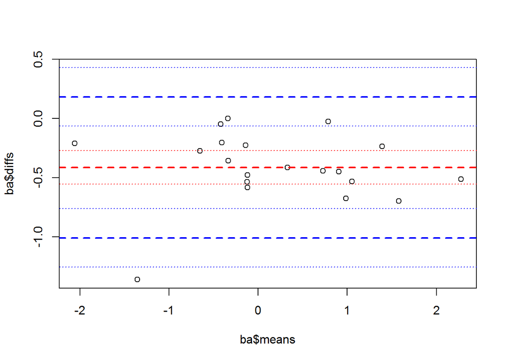

```r
# or in base-graphics:
bland.altman.plot(A, B, conf.int=.95)
```

## Sunflower-Option

Sometimes data have ties. Imagine your test is a questionnaire which will only ever give scores between 0 and 10 and you are checking retest-agreement:

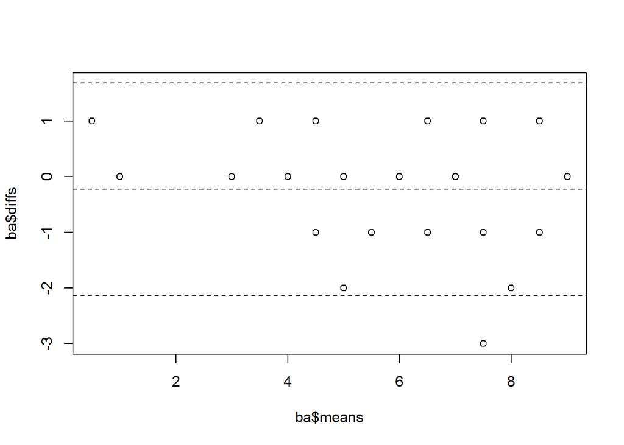

```r
A <- c(7, 8, 4, 6, 4, 5, 9, 7, 5, 8, 1, 4, 5, 7, 3, 4, 4, 9, 3, 3,
1, 4, 5, 6, 4, 7, 4, 7, 7, 5, 4, 6, 3, 4, 6, 4, 7, 4, 6, 5)
B <- c(8, 7, 4, 6, 3, 6, 9, 8, 4, 9, 0, 5, 5, 9, 3, 5, 5, 8, 3, 3,
1, 4, 4, 7, 4, 8, 3, 7, 7, 5, 6, 7, 3, 3, 7, 3, 6, 5, 9, 5)

bland.altman.plot(A, B)
```

Obviously there is a lot of ties in these data. There are 21 data points visible even though there are 40 data points contained. That is why the BlandAltmanLeh packages offers a sunflower plot as the basis of a Bland-Altman plot for data with ties:

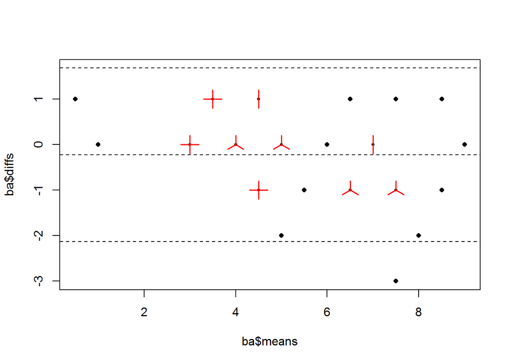

```r
bland.altman.plot(A, B, sunflower=TRUE)
```

Unfortunately, this option does not exist with ggplot2 output. However, if you want to make a plot of your own you can still use the BlandAltmanLeh package to compute the statistics behind the Bland-Altman plot as in this little example, where male and female data are to be drawn in different colors:

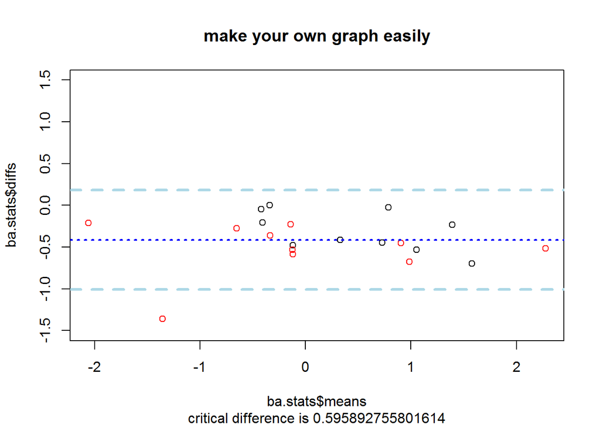

```r
A <- c(-0.358, 0.788, 1.23, -0.338, -0.789, -0.255, 0.645, 0.506,
0.774, -0.511, -0.517, -0.391, 0.681, -2.037, 2.019, -0.447,
0.122, -0.412, 1.273, -2.165)
B <- c(0.121, 1.322, 1.929, -0.339, -0.515, -0.029, 1.322, 0.951,
0.799, -0.306, -0.158, 0.144, 1.132, -0.675, 2.534, -0.398, 0.537,
0.173, 1.508, -1.955)
sex <- c( 1,1,1,1,2,2,2,1,1,1,2,2,2,2,2,1,1,2,1,2)

ba.stats <- bland.altman.stats(A, B)

plot(ba.stats$means, ba.stats$diffs, col=sex,
     sub=paste("critical difference is",ba.stats$critical.diff),
     main="make your own graph easily", ylim=c(-1.5,1.5))
abline(h = ba.stats$lines, lty=c(2,3,2), col=c("lightblue","blue","lightblue"),
       lwd=c(3,2,3))
```

Thus, you have the full flexibility of the R graphic systems but no need to worry about details like missing data etc.

Find an example of an ggplot2 bland.altman.plot combined with a regression line and regression confidence intervall on this poster in fig 3: Evans R, Gonnermann U, Koch A, Lehnert B, GMS Curr Posters Otorhinolaryngol Head Neck Surg 2015; 11:Doc310 (20150416) http://www.egms.de/static/pdf/journals/cpo/2015-11/cpo001275.pdf

# Yet another Bland-Altman procedure? What’s in a name?

With Bland-Altman plots being a standard analysis, one should think, there are lots of packages on CRAN. Yes, there are:

- Package **PairedData** has a function plotBA based on ggplot2 (and I prefer base plots) and no stats as return value
- Package **ResearchMethods** has a function BlandAltman which focuses on a GUI and has no return values.
- Package **epade has** a function bland.altman.ade which appears to have no return values.
- Package **MethComp** has a functino BlandAltman that is deprecated and a function ba.plot which does a lot, mainly regression and from first glance seems to be worthy of further investigation for serious work.
- There are **probably other packages** that I did not mention. There I did not want to give this package a name like RBlandAltman but state, that this is just humble one approach by one Person (Lehnert) and therefore BlandAltmanLeh

# Last but not least

Before using this in any serious work consider the version number and perform plausibility checks.

Enjoy!

Bernhard Lehnert, University Medicine Greifswald, Germany